#### 23.11.23, © Kudryavets Yehor KI-21-1, 2023

# Лабораторна робота 3. OpenCV. Просторові методи обробки зображень І. Градаційні перетворення і гістограмні методи (short version)

**Мета:** знайомство з поелементними і гістограмними просторовими методами обробки зображень засобами OpenCV у середовищі Anaconda із застосуванням Jupyter Notebook засобами мови програмування Python.

# Хід роботи

1.Виконати петворення фото у Негатив.

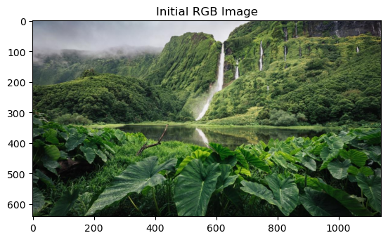

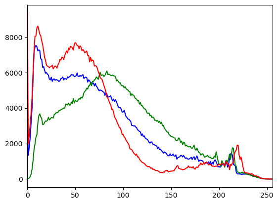

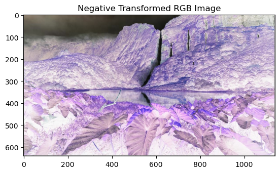

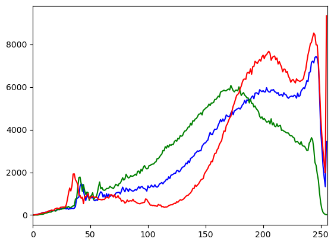

```python
import cv2
import matplotlib.pyplot as plt

initial_img_rgb = cv2.imread('img/Nature.jpg', cv2.IMREAD_COLOR)
initial_img_rgb = cv2.cvtColor(initial_img_rgb, cv2.COLOR_BGR2RGB)
plt.imshow(initial_img_rgb)
plt.title('Initial RGB Image')
plt.show()

colors = ('b', 'g', 'r')

for i, col in enumerate(colors):
    hist_rgb = cv2.calcHist([initial_img_rgb],
                            [i], None,
                            [256],
                            [0, 256])

    plt.plot(hist_rgb, color=col)
    plt.xlim([0, 256])

plt.show()

height, width, _ = initial_img_rgb.shape
for i in range(0, height - 1):
    for j in range(0, width - 1):

        pixel = initial_img_rgb[i, j]
        pixel[0] = 255 - pixel[0]
        pixel[1] = 255 - pixel[1]
        pixel[2] = 255 - pixel[2]

        initial_img_rgb[i, j] = pixel
plt.imshow(initial_img_rgb)
plt.title('Negative Transformed RGB Image')
plt.show()

colors = ('b', 'g', 'r')

for i, col in enumerate(colors):

    hist_transformed_rgb = cv2.calcHist([initial_img_rgb],
                                        [i], None,
                                        [256],
                                        [0, 256])

    plt.plot(hist_transformed_rgb, color=col)
    plt.xlim([0, 256])
plt.show()
```

Градаційне перетворення для отримання негативу зображення використовується для інверсії яскравості пікселів, щоб створити зображення з оберненими кольорами. Формула градаційного перетворення для отримання негативу:

$G(x,y)=L−1−F(x,y)$

де:

- $G(x,y)$ - нова яскравість пікселя після градаційного перетворення,
- $F(x,y)$ - початкова яскравість пікселя,
- $L$ - максимальна можлива яскравість пікселя (зазвичай 256 для 8-бітових зображень).

Ця формула виконує віднімання початкової яскравості пікселя з максимально можливої яскравості, і потім віднімає результат від 1. Це призводить до обернення значень яскравості та отримання негативного зображення.

2.Виконати логарифмічні перетворення з фотографією

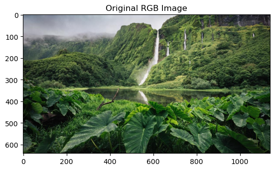

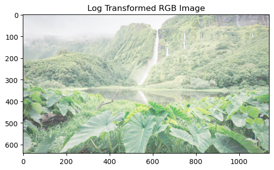

```python
import cv2
import numpy as np
import matplotlib.pyplot as plt

original_image = cv2.imread('img/Nature.jpg')

original_image_rgb = cv2.cvtColor(original_image, cv2.COLOR_BGR2RGB)

epsilon = 1e-8
c_value = 255 / np.log(1 + np.max(original_image_rgb) + epsilon)
log_transformed_image = c_value * (np.log(original_image_rgb + epsilon))

log_transformed_image = np.nan_to_num(log_transformed_image)

log_transformed_image = np.array(log_transformed_image, dtype=np.uint8)

plt.imshow(original_image_rgb)
plt.title('Original RGB Image')
plt.show()

plt.imshow(log_transformed_image)
plt.title('Log Transformed RGB Image')
plt.show()
```

Логарифмічне перетворення використовується для розширення динамічного діапазону яскравості зображення та підвищення видимості деталей в темних областях. Формула логарифмічного градаційного перетворення виглядає наступним чином:

$G(x,y)=c⋅log(1+F(x,y))$

де:

- $G(x,y)$ - нова яскравість пікселя після логарифмічного градаційного перетворення,
- $F(x,y)$ - початкова яскравість пікселя,
- $c$ - константа, яка визначає ступінь логарифмічного перетворення(зазвичай $с≈\frac{L−1}{log(L)}$ де

$L$ - максимальна можлива яскравість пікселя).

Ця формула застосовує логарифм до кожного значення яскравості пікселя, збільшуючи контрастність в темних областях зображення та зменшуючи її в світлих.

3.Виконати степеневу(гамма-коеркцію) з фотографією

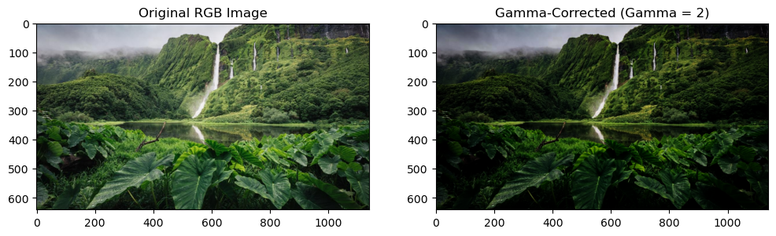

```python
import cv2
import numpy as np
import matplotlib.pyplot as plt

original_image = cv2.imread('img/Nature.jpg')
original_image_rgb = cv2.cvtColor(original_image, cv2.COLOR_BGR2RGB)
gamma_value = 2

gamma_corrected_image = np.power(original_image_rgb / 255.0, gamma_value)
gamma_corrected_image = np.uint8(gamma_corrected_image * 255.0)
fig, axes = plt.subplots(1, 2, figsize=(12, 6))

axes[0].imshow(original_image_rgb)
axes[0].set_title('Original RGB Image')

axes[1].imshow(gamma_corrected_image)
axes[1].set_title(f'Gamma-Corrected (Gamma = {gamma_value})')

plt.show()
```

Степенева (гамма-коеркція) трансформація використовується для корекції гамми або зміни контрасту в зображенні. Формула гамма-коеркції виглядає наступним чином:

$G(x,y)=c⋅[F(x,y)]^γ$

де:

- $G(x,y)$ - нова яскравість пікселя після гамма-коеркції,
- $F(x,y)$ - початкова яскравість пікселя,
- $c$ - константа масштабування,
- $γ$ - параметр гамми (зазвичай від 0,1 до 5).

Ця формула підносить кожне значення яскравості пікселя до ступеня γ, тим самим коригуючи контраст та яскравість зображення. Зменшення значення гамми (<1) зменшує контраст, тоді як збільшення значення гамми (>1) збільшує контраст.

4.Виконати соляризацію зображення

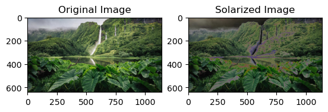

```python
import cv2
import numpy as np
import matplotlib.pyplot as plt

original_image = cv2.imread('img/Nature.jpg')
blue, green, red = cv2.split(original_image)
threshold_value = 128

solarized_blue = np.where(blue < threshold_value, blue, 255 - blue)
solarized_green = np.where(green < threshold_value, green, 255 - green)
solarized_red = np.where(red < threshold_value, red, 255 - red)

solarized_image = cv2.merge((solarized_blue, solarized_green, solarized_red))

plt.subplot(1, 2, 1)
plt.imshow(cv2.cvtColor(original_image, cv2.COLOR_BGR2RGB))
plt.title('Original Image')

plt.subplot(1, 2, 2)
plt.imshow(cv2.cvtColor(solarized_image, cv2.COLOR_BGR2RGB))
plt.title('Solarized Image')

plt.show()
```

де:

- $G(x,y)$ - нова яскравість пікселя після соляризації,
- $F(x,y)$ - початкова яскравість пікселя,
- $L$ - максимальна можлива яскравість пікселя (зазвичай 256 для 8-бітових зображень).

Ця формула застосовує соляризацію шляхом створення відзеркаленого ефекту відносно середнього відтінку (половина максимальної яскравості). Такий підхід може забезпечити ефект соляризації в околицях контурів об'єктів на зображенні.

5.Застосувати еквалізацію гістограми до зображення

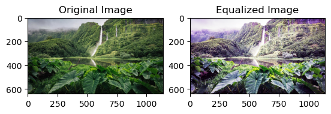

```python
import cv2
import numpy as np
import matplotlib.pyplot as plt

original_image = cv2.imread('img/Nature.jpg')
blue, green, red = cv2.split(original_image)

equalized_blue = cv2.equalizeHist(blue)
equalized_green = cv2.equalizeHist(green)
equalized_red = cv2.equalizeHist(red)

equalized_image = cv2.merge((equalized_blue, equalized_green, equalized_red))

plt.subplot(1, 2, 1)
plt.imshow(cv2.cvtColor(original_image, cv2.COLOR_BGR2RGB))
plt.title('Original Image')

plt.subplot(1, 2, 2)
plt.imshow(cv2.cvtColor(equalized_image, cv2.COLOR_BGR2RGB))
plt.title('Equalized Image')

plt.show()
```

6.Виконати оцінку гістограми кольорового зображення

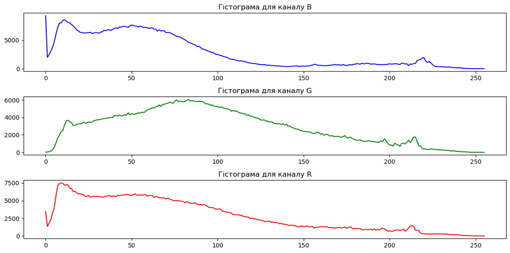

```python
import cv2
import numpy as np
import matplotlib.pyplot as plt

image = cv2.imread('img/Nature.jpg')
b, g, r = cv2.split(image)
hist_b = cv2.calcHist([b], [0], None, [256], [0, 256])
hist_g = cv2.calcHist([g], [0], None, [256], [0, 256])
hist_r = cv2.calcHist([r], [0], None, [256], [0, 256])
plt.figure(figsize=(12, 6))

plt.subplot(3, 1, 1)
plt.plot(hist_b, color='blue')
plt.title('Гістограма для каналу B')

plt.subplot(3, 1, 2)
plt.plot(hist_g, color='green')
plt.title('Гістограма для каналу G')

plt.subplot(3, 1, 3)
plt.plot(hist_r, color='red')
plt.title('Гістограма для каналу R')

plt.tight_layout()
plt.show()
```

Гістограма для кожного кольорового каналу (синього, зеленого, червоного) надає інформацію про розподіл інтенсивності пікселів у відповідних кольорових компонентах на зображенні.наліз гістограм дозволяє визначити діапазони яскравості кожного каналу. Високі піки в гістограмі можуть вказувати на насиченість певного діапазону яскравості, тоді як широкі гістограми можуть свідчити про широкий розподіл.Величина та форма гістограми можуть слугувати показниками контрастності та динаміки зображення. Широкі гістограми зазвичай вказують на великий діапазон яскравості та виражену контрастність.Аналіз гістограми може допомогти визначити, чи є експозиція зображення оптимальною. Затемнення або пересичення гістограми на краях може свідчити про недостатню експозицію або пересичення.На підставі гістограм можна виробити рішення щодо корекції зображення. Наприклад, еквалізація гістограми може бути використана для покращення контрасту та збалансування яскравості каналів.

## Контрольні запитання

1.У чому полягає сенс градаційних перетворень?

Градаційні перетворення використовуються для зміни інтенсивності або колірної гами зображення. Сенс таких перетворень полягає в можливості налаштовувати контраст, яскравість та інші характеристики зображення, щоб впливати на його зовнішній вигляд.

Основні аспекти градаційних перетворень включають:

- контраст: Збільшення або зменшення контрасту може зробити зображення більш насиченим або менш насиченим, відзначаючи або заглушуючи деталі.
- яскравість: Зміна яскравості дозволяє регулювати загальний рівень світла на зображенні.
- насиченість: Зміна насиченості впливає на інтенсивність кольорів на зображенні, дозволяючи зробити їх більш яскравими або приглушеними.
- тон і відтінок: Градаційні перетворення також можуть впливати на тон та відтінок, дозволяючи коригувати колірний баланс.
- експозиція: Регулювання експозиції дозволяє контролювати, наскільки світле чи темне стане зображення.

2.На чому ґрунтуються гістограмні методи?

Гістограмні методи ґрунтуються на аналізі гістограми зображення, яка відображає розподіл інтенсивності пікселів. Ці методи дозволяють визначати контраст, експозицію та розподіл інтенсивності в зображенні. Ширший розподіл гістограми може свідчити про великий контраст, в той час як стислий розподіл вказує на низький контраст. Графічне відображення гістограми також допомагає виявляти переповнення та потемніння в зображенні, що є важливим для корекції та покращення властивостей зображень. Гістограмні методи широко використовуються в обробці зображень для визначення та коригування їхніх характеристик.

## References

1.https://github.com/wtfpanda007/Python - посилання на GitHub-репозиторій